# Coursework Report

*N* removed NAs: 2

*N* removed typo: 1

*N* removed <18: 24

*N* total clean: 123

| Group | *N* | *M*<sub>age</sub> | *M*<sub>rating</sub> |
| --- | --- | --- | --- |
| Control | 61 | 20.75 | 6.60 |
| Experim | 62 | 20.74 | 5.75 |

**Main analysis results**

*t*(121) = 5.49, *p* < .001

[interactive chart not shown]

[figure not shown]

[interactive chart not shown]

# Coursework Report

Analysing Data, Spring 2020

# Method

The aim of this study was to investigate how the colour red influences perceived attractiveness in males.

## **Participants**

The study consisted of 150 participants. All participants were female. After participating in the experiment, data from 27 participants was removed due to either not meeting the age requirements or not recording their age. This resulted in 123 participants remaining in the data set which was then statistically analysed (Mean age = 20.75, SD age = 1.94,Age Range = 18 - 29).The total number of participants was split with 61 in the control condition and 62 in the experimental condition. The experimental condition had a mean age of 20.74 with a range of 18 - 28. Similarly, the control condition had a mean age of 20.75 with the ages range from 18 - 29.

###### Table one shows the age statistics across the whole cohort of participants.

Table 1. Age Descriptive of the Participant Cohort

| Mean age | SD Age | Min Age | Max Age |
| --- | --- | --- | --- |
| 20.75 | 1.94 | 18 | 29 |

###### Table two shows the age statistics categorised by condition.

Table 2. Age Statistics by Experimental Condition.

| Group | Mean age | SD Age | Minimum Age | Maximum Age |
| --- | --- | --- | --- | --- |
| Control | 20.75 | 1.89 | 18 | 29 |
| Experimental | 20.74 | 2.01 | 18 | 28 |

## Design

This study aimed to answer the question of whether women’s perceptions of attractiveness are influenced by colour specifically the colour red.

In this study, participates were randomly assigned to one of two group, a white condition and red condition. Both conditions were shown a black and white picture of a Caucasian man. The control condition saw the picture on a white background whilst the experimental condition saw the picture with a red background. Levels of perceived attractiveness of the man were recorded. This perceived attractiveness was operationalised with three questions identified as measures, “How attractive do you think this person is?” “How pleasant is this person to look at?” and “If I were to meet the person in this picture face to face, I would think he is attractive.”. These questions were answered by rating on an attractiveness scale from 1 being not attractive at all to 9 being extremely attractive. The mean scores represent the attractiveness across all participants within the condition and the measure. A high mean score can be interpretative as a greater perceived attractiveness. This study will test whether the colours, red or white effect women’s perception of attractiveness in Caucasian men. An independent t-test will be used to assess whether the results are significant and whether the hypothesis can be accepted.

# Results

###### Table three shows the Perceived attractiveness scores by condition and measure

Table 3. Perceived Attractiveness Means and SD by Condition and Measure

| Condition | N | Tests of perceived attractiveness Measure 1 Mean | Tests of perceived attractiveness Measure 1 SD | Tests of perceived attractiveness Measure 2 Mean | Tests of perceived attractiveness Measure 2 SD | Tests of perceived attractiveness Measure 3 Mean | Tests of perceived attractiveness Measure 3 SD |
| --- | --- | --- | --- | --- | --- | --- | --- |
| Control | 61 | 6.67 | 1.43 | 6.69 | 1.51 | 6.43 | 1.56 |
| Experimental | 62 | 5.82 | 1.65 | 5.56 | 1.44 | 5.85 | 1.52 |

Note:

<sup>1</sup> Footnote 1; All perceived attractiveness measures were rated on a 9-point scale

Table 3 illustrates how perceived attractiveness scores varied across the different conditions and measures. The means for the control condition across all three attractiveness measures were consistently higher and significantly higher than in the experimental condition.

###### Table four shows the standard deviation for the percieved attarctiveness scores by condition

Table 4. Standard deviation of Perceived Attractiveness Scores by Condition

| Condition | Perceived attractiveness score Composite SD |
| --- | --- |
| Control | 1.50 |
| Experimental | 1.54 |

Table 4 displays the standard deviations of the Perceived attractiveness scores according to the conditions. It shows that the standard deviation value for the experimental condition is greater than the control condition. This means that there is a greater spread of scores around the mean in the experimental condition compared to the control condition, indicating that there is a greater variety of attractiveness scores in the experimental condition.

###### Table five shows the composite means scores for percieved attractiveness by condition

Table 5. Composite means of attractiveness by Conditions

| Condition | Perceived attractiveness score Composite mean |
| --- | --- |
| Control | 6.60 |
| Experimental | 5.75 |

Note:

<sup>1</sup> Footnote 1; All perceived attractiveness measures were rated on a 9-point scale

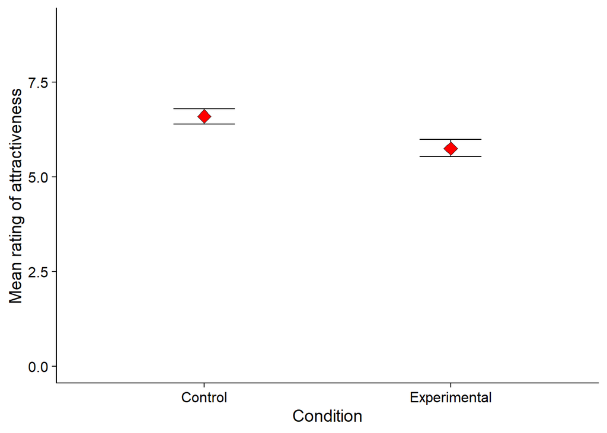

The graph above and table five display how mean rating of attractiveness varied across the two conditions.The graph shows pictorially that the mean perceived attractiveness score was higher in the control condition compared to the experimental condition. The results were changed to be formulated as mean composite scores. These scores are the sum of the attractiveness scores according to the three measures divided by the total number of scores.

# Discussion

This discussion will summarise the supporting and contradictory results of the red effect and will consider its significance.

This study examines the red effect in younger women, therefore we cannot infer how older women would respond. This study cannot comment directly on Schwarz & Singer, (2013) research investigating whether the red effect can be generalised to other aged women, especially menopausal women. It is possible to suggest that discrepancies in effect of red on attractiveness does exist within younger women. These results cannot comment on the “red effect” in relation to naturally occurring red colouration of skin (Lin, 2014) (Pazda et al., 2016) therefore it is not possible to compare findings with naturally red occurring manipulation and its effect on perceived attractiveness. Additionally, due to the specified demographic of the male being Caucasian, it results in an inability to comment on how this effect differ amongst other ethnic demographics (Williams et al., 2017). It could be suggested that future research could investigate the “red effect” within black, Hispanic and other ethnicities. This would provide depth to the red effect and widen the perspective on its effect. Although this study replicated the same age group, the ethnicities and cultural influences within this sample may not have been replicated; this could lead to differing results.

Additionally, this study does fail to address outstanding issues, for example how menstrual cycle variation impacts the red effect. Research by Gildersleeve et al., (2014) has found that unconscious perceived attractiveness preferences differ across the menstrual cycle and therefore this raises the curiosity of whether the red effect is included within these transient attractiveness preferences. This study cannot comment on the possible impact of the menstrual cycle on the red effect, therefore fails to identify a possible confounding variable. To avoid this in the future, research surrounding the red effect could involve testing the female participants to identify their current menstrual cycle stage. This would help identify whether this confounds with the level of impact that red has on the attractiveness scores. This may give greater insight into why inconsistent findings within the “red effect” are found and raises future research questions of; why the red effect only impacts some people and from an evolutionary perspective, why is red a preferred colour. Alongside this, most existing research in regard to the “red effect” focuses on opposite sex attraction preferences, the results from this study can provide no indication of the significance of the red effect within same-sex attractiveness. This highlights an area of further study, specifically whether the “red effect” exists within same-sex attraction. By studying this area of perceived attractiveness questions surrounding the paradigm in which the red effect occurs could be answered.

Further studies need to be conducted in order to fully understand the underlying reasons for the red effect and specifically which context and situations the “red effect” has most impact. It is essential to study these unconscious biases which underlying decisions specifically surrounding attraction as this has real life application in choosing future partners, and encouraging successful decisions.

# References

Elliot, A. J., & Niesta, D. (2008). Romantic Red: Red Enhances Men’s Attraction to Women. *Journal of Personality and Social Psychology*, 95(5), 1150–1164. Scopus. https://doi.org/10.1037/0022-3514.95.5.1150

Elliot, A. J., Niesta Kayser, D., Greitemeyer, T., Lichtenfeld, S., Gramzow, R. H., Maier, M. A., & Liu, H. (2010). Red, Rank, and Romance in women viewing men. *Journal of Experimental Psychology: General*, 139(3), 399–417. Scopus. https://doi.org/10.1037/a0019689

Gildersleeve, K., Haselton, M. G., & Fales, M. R. (2014). Do women’s mate preferences change across the ovulatory cycle? A meta-analytic review. *Psychological Bulletin* , 140(5), 1205–1259. https://doi.org/10.1037/a0035438

Lin, H. (2014). Red-colored products enhance the attractiveness of women. *Displays*, 35(4), 202–205. https://doi.org/10.1016/j.displa.2014.05.009

Pazda, A. D., Thorstenson, C. A., Elliot, A. J., & Perrett, D. I. (2016). Women’s Facial Redness Increases Their Perceived Attractiveness: Mediation Through Perceived Healthiness: *Perception*. https://doi.org/10.1177/0301006616633386

Peperkoorn, L. S., Roberts, S. C., & Pollet, T. V. (2016). Revisiting the Red Effect on Attractiveness and Sexual Receptivity: No Effect of the Color Red on Human Mate Preferences. *Evolutionary Psychology*, 14(4), 1474704916673841. https://doi.org/10.1177/1474704916673841

Schwarz, S., & Singer, M. (2013). Romantic red revisited: Red enhances men’s attraction to young, but not menopausal women. *Journal of Experimental Social Psychology*, 49(1), 161–164. https://doi.org/10.1016/j.jesp.2012.08.004

Thorstenson, C. A., Pazda, A. D., Elliot, A. J., & Perrett, D. I. (2017). Facial redness increases men’s perceived healthiness and attractiveness. *Perception*, 46(6), 650–664. http://dx.doi.org/10.1177/0301006616680124

Wang, C.-A., Baird, T., Huang, J., Coutinho, J. D., Brien, D. C., & Munoz, D. P. (2018). Arousal Effects on Pupil Size, Heart Rate, and Skin Conductance in an Emotional Face Task. *Frontiers in Neurology* , 9. https://doi.org/10.3389/fneur.2018.01029

Williams, L. A., Schofield, T. P., & Whitford, T. J. (2017). Romantic Red: Testing the Characteristics of Color–Attraction Effects in a Novel Paradigm. *Collabra: Psychology* , 3(1), 10. https://doi.org/10.1525/collabra.54